# Assignment

240 points

Author

Esteban Montenegro-Montenegro

Published

May 21, 2025

## Description

In this third assignment, you’ll have to solve several applied tasks. This means you’ll have to use `R` in some parts to analyze data sets. In other parts, you’ll need to answer theoretical questions based on the slides provided in class. I will also provide the book chapters on Canvas. When I need you to pay attention to a detail in a book chapter, I’ll mention the chapter and page where you can find the detail I need you to pay attention.

## Part 1: Review important concepts

In this section, you will see TRUE/FALSE questions, or multiple choice questions. Select only one option. **(10 points each correct answer)**.

Please copy the question along with your answer in a Word document.

1. A $t$-test may be used when my dependent variable is continuous and the independent variable is a nominal variable with only two levels:

True  
False

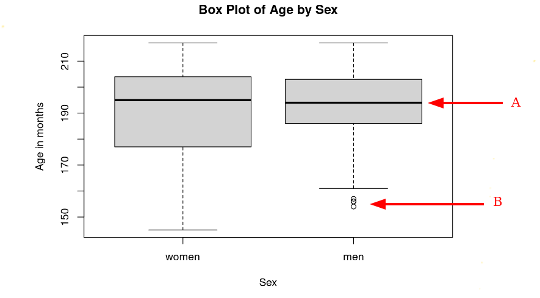

2. The options to label A and B are: `(check the module "Data Visualizations on Canvas")`

A.Regression line, B.Outliers  
A.Mean, B.Median  
A.Median, B.Outliers

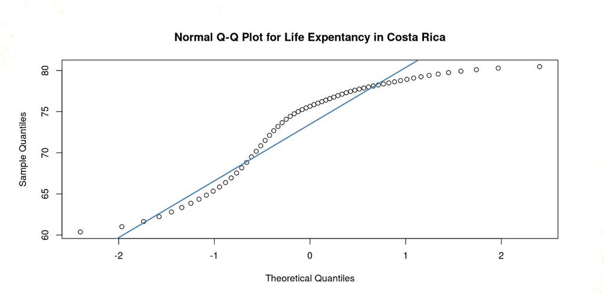

3. The above figure is a QQ-plot, can you conclude that Life Expectancy in Costa Rica comes from a normally distributed process? `(check the module "Data Visualizations on Canvas")`

Yes  
No

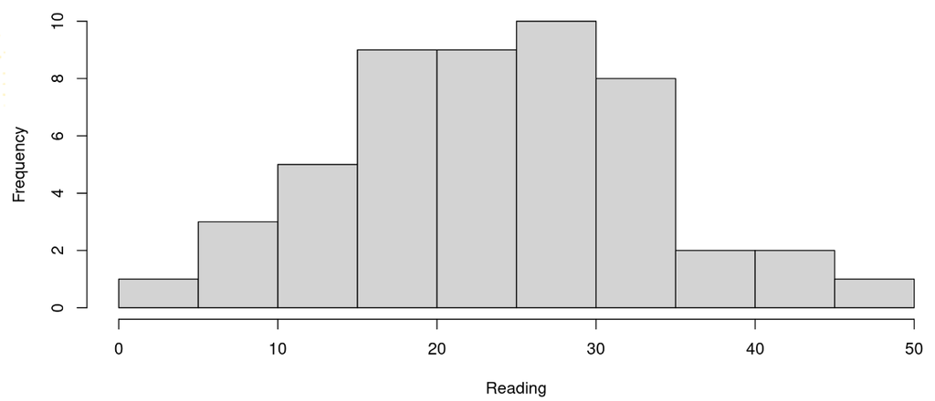

4. The above figure represents a:

Density plot  
Bar plot  
Histogram  
Scatter plot

5. In the Classical Regression Model, the estimated slope of the regression is often represented with the Greek letter $\beta$ (beta). Taking this into consideration, if my estimated $\beta$ is equals to a value greater than $0$, I can conclude that there is a positive relationship between my outcome and my predictor:

True  
False

6. The Classical Regression Model does not have any distributional assumption on the predictors

True  
False

7. The Classical Regression Model assumes that the dependent variable or outcome must come from a normal distribution:

True  
False

8. The following model represents:

$$\begin{equation}
Y = \beta_{0}+ \beta_{1}X_{1} + \beta_{2}X_{2} + \epsilon
\end{equation}$$

t-test  
Correlation  
Classical Regression Model  
None of the above

9. One of the assumptions of ANOVA is constant variance in all groups:

True  
False

10. Pedro performed an experiment aiming to delay dementia symptoms in older adults. In this study, Pedro created three random conditions: A) A group attending yoga class, B) A group attending weight lifting, and finally, C) A group attending nutrition classes. Pedro measured the working memory capacity at the end of the study as a dependent variable. The problem for Pedro is that he doesn’t know which statistical model he should estimate.

What model should Pedro estimate on his data to test the mean differences between groups?

t-test  
Pearson correlation  
ANOVA  
None of the above

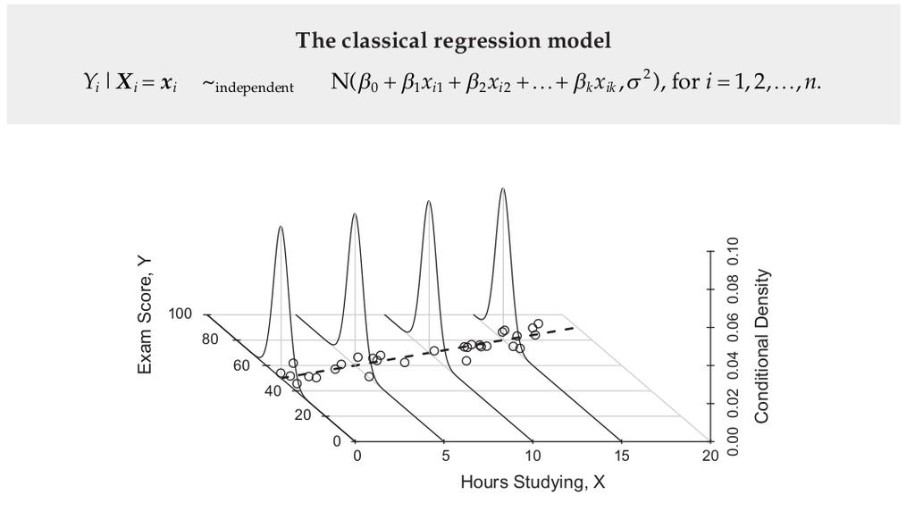

11. According to the figure above, the Classical Regression Model assumes that the conditional probability distribution functions $p(y|x)$ (y given x) are normal distributions:

True  
False  
There is not enough information to answer the question

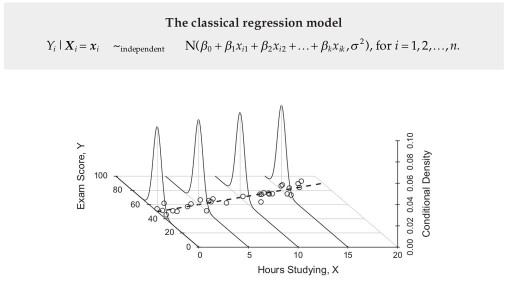

12. Again, following the figure above, we can say that the dashed line represents the linearity assumption:

True  
False  
There is not enough information to answer the question

13. We can include nominal variables as predictors in a Classical Regression Model, but first we need to create *dummy coded* variables:

True  
False

14. The Classical Regression Model requires a continuous dependent variable:

True  
False

15. The following table represents:

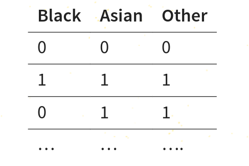

An experiment  
A correlation matrix  
A set of dummy coded variables  
Means and standard deviations  
None of the above

## Second Part: Short answer questions

In this section, I expect short answers, where you explain in your own words relevant concepts:

1. Explain in your own words how to transform a nominal variable into several *dummy coded* variables. You may provide an example to make your explanation easier to follow. (20 points)
2. Describe the assumptions of the Classical Regression Model, you may check the lecture `Correlation and Regression Models Part 2`. (15 points)

## Third Part: Playing with `R` and perhaps `JAMOVI`.

In this part you will use `R` to answer several questions, the questions are a guide into different steps when performing an ANOVA.

You will use the data file named `anovaData.csv`, you may download the file from [here](https://mega.nz/file/mVMHHIoA#b3ePMSQ_mJ8O1rnnSEa3DJZXwpcdb1jfhXnPkb6u6b4).

You may also open the data file in `R` after running the following code:

```r
url <- "https://raw.githubusercontent.com/blackhill86/mm2/refs/heads/main/dataSets/anovaData.csv"

camcog <- read.csv(url)
```

The data for this exercise is real data from an experimental intervention performed in Costa Rica in 2011. In this study, we aimed to answer the following question:

*Will an intervention focus on improving autobiographical memory delay dementia symptoms?*

Based on this question, we design an experiment where we assign aging adults to 4 different conditions:

- *Condition A*: Participants with mild cognitive impairment received the intervention.
- *Condition B*: Participants with mild cognitive impairment *did not* receive the intervention.
- *Condition C*: Healthy participants without cognitive impairment received the treatment.
- *Condition D*: Healthy participants without cognitive impairment *did not* receive the treatment.

We measured the cognitive performance of the participants as dependent variable. The cognitive performance was measured before the intervention started, and it was measured again once the intervention finished. We utilized the Cambridge Cognition Examination (CAMCOG) to determine their cognitive performance. This is a long battery of tests, and at the end you can compute a total score that represents the cognitive status.

Higher scores in the CAMCOG are evidence of better cognitive performance, while lower scores represent a low cognitive performance.

After this explanation I hope the content of the data is starting to make sense. In the data set `anovaData.csv` you will find the following columns:

- *ID:* The study identification number for each participant.
- *CAMCOG_pre:* the total score before the intervention started.
- *CAMCOG_post:* the total score after the intervention finished.
- *Group*: The intervention group where:
  - **A:** Participants with mild cognitive impairment received the intervention.
  - **B:** Participants with mild cognitive impairment *did not* receive the intervention.
  - **C:** Healthy participants without cognitive impairment received the treatment.
  - **D:** Healthy participants without cognitive impairment *did not* receive the treatment.
1. Report the means and standard deviations of the `CAMCOG_post` by `Group`, report the table from `R`. In addition, create a plot in `R` showing the mean values of `CAMCOG_post` by `Group`. (20 points)
2. Interpret the estimated mean values. Do you see a large difference in the mean score when comparing healthy aging adults versus aging adults with dementia? Do you observe in the bar plot a remarkable difference between groups `A` and `B`? ( 5 points)
3. ANOVA has two important assumptions, constant variance and normality. Perform the Shapiro-Wilk’s test, to asses the normality assumption, and the Levene’s test to evaluate the assumption of constant variance. (10 points).
4. Perform an *omnibus* ANOVA analysis to determine if there is any mean difference not explained by chance alone. Paste the table from `R` in your answer (10 points).
5. According to the $p$-value. What is your conclusion? (5 point)
6. At this point we have performed a *omnibus* test, this test does not tell which group differs beyond chance from the other groups. Perform a *post-hoc* analysis to determine where are the differences between groups and which differences are not explained by chance alone. Report the table generated in `R`. After that, interpret the results. (5 points)